# Problema 2: Propiedades de los estimadores

Simulación, Estimación e Inferencia Estadística · 2026-A

Integrantes: Juan Alejandro Carrillo Jaimes & David Burgoa

2026-03-22

# 1 Descripción del Problema

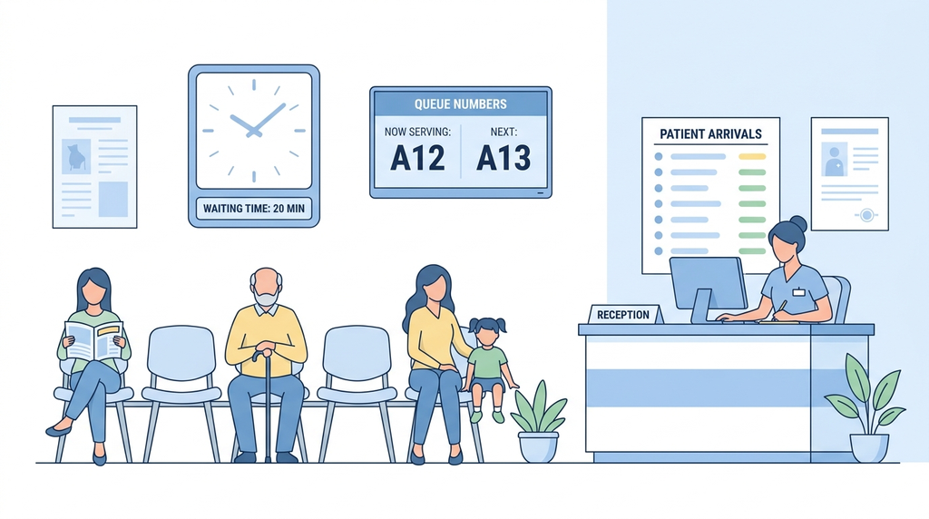

Figure 1.1: Centro de atención médica

Un centro de atención médica registra el tiempo de espera (en minutos) de los pacientes antes de ser atendidos. Se sabe que estos tiempos siguen una distribución Gamma con parámetros conocidos $\alpha = 3$ (forma) y $\sigma = 2$ (escala). El parámetro de interés es la media poblacional:

$$\mu = \alpha \cdot \sigma = 3 \times 2 = 6 \text{ minutos}$$

Sea $X_1, X_2, \dots, X_n$ una muestra aleatoria de tamaño $n$ i.i.d. extraída de esta población. Se proponen los siguientes estimadores para $\mu$:

$$\hat{\mu}_1 = \frac{1}{n}\sum_{i=1}^n X_i \qquad
\hat{\mu}_2 = \frac{\min(X_1,\dots,X_n) + \max(X_1,\dots,X_n)}{2}$$

$$\hat{\mu}_3 = X_{(1)} \qquad
\hat{\mu}_4 = \frac{1}{n+1}\sum_{i=1}^n X_i$$

```r
# Parámetros poblacionales
alpha_g <- 3
sigma_g <- 2
mu_pob  <- alpha_g * sigma_g  # Media poblacional = 6
cat("Media poblacional (μ = α·σ):", mu_pob, "minutos\n")
```

```
## Media poblacional (μ = α·σ): 6 minutos
```

## 1.1 Simulación de estimadores

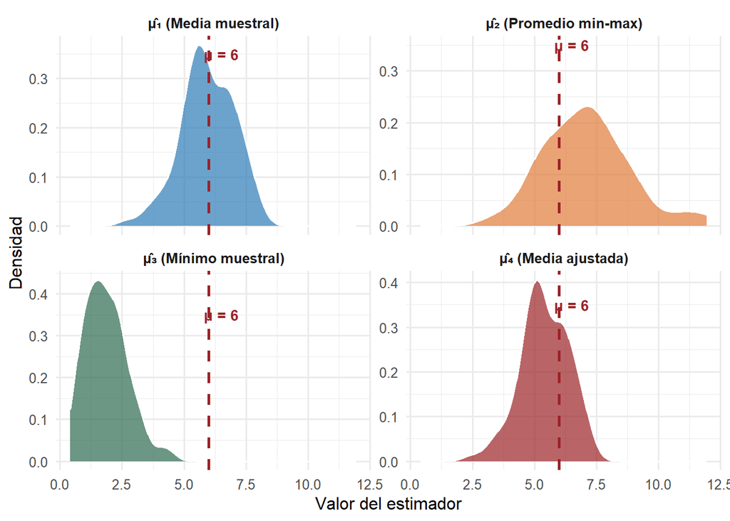

Figure 1.2: Distribución de los cuatro estimadores — 100 muestras de n = 10

```r
set.seed(1005062032) # Codigo: Est Juan Alejandro Carrillo Jaimes
n_sim <- 10
m_sim <- 100

muestras <- replicate(m_sim, rgamma(n_sim, shape = alpha_g, scale = sigma_g))

est1 <- apply(muestras, 2, mean)
est2 <- apply(muestras, 2, function(x) (min(x) + max(x)) / 2)
est3 <- apply(muestras, 2, min)
est4 <- apply(muestras, 2, function(x) sum(x) / (n_sim + 1))

df_est <- data.frame(
  valor     = c(est1, est2, est3, est4),
  estimador = rep(c("μ̂₁ (Media muestral)",
                    "μ̂₂ (Promedio min-max)",
                    "μ̂₃ (Mínimo muestral)",
                    "μ̂₄ (Media ajustada)"), each = m_sim)
)

ggplot(df_est, aes(x = valor, fill = estimador)) +
  geom_density(alpha = 0.7, color = "white") +
  geom_vline(xintercept = mu_pob, linetype = "dashed",
             color = "#9b2226", linewidth = 1) +
  annotate("text", x = mu_pob + 0.5, y = 0.35,
           label = paste0("\u03bc = ", mu_pob),
           color = "#9b2226", size = 3.5, fontface = "bold") +
  facet_wrap(~estimador, scales = "free_y", ncol = 2) +
  scale_fill_manual(values = c("#2c7bb6","#e07b39","#2d6a4f","#9b2226")) +
  labs(x = "Valor del estimador", y = "Densidad") +
  theme_minimal(base_size = 12) +
  theme(legend.position = "none",
        strip.text = element_text(face = "bold"))
```

La Figura 1.2 muestra que $\hat{\mu}_1$ y $\hat{\mu}_4$ presentan distribuciones centradas cerca de $\mu = 6$, mientras que $\hat{\mu}_3$ (mínimo muestral) se concentra en valores bajos, lejos del parámetro real. $\hat{\mu}_2$ muestra mayor dispersión que $\hat{\mu}_1$.

## 1.2 Insesgadez

Un estimador $\hat{\mu}$ es **insesgado** si $E[\hat{\mu}] = \mu$. El sesgo se define como:

$$\text{Sesgo}(\hat{\mu}) = E[\hat{\mu}] - \mu$$

```r
sesgos <- data.frame(
  Estimador  = c("μ̂₁", "μ̂₂", "μ̂₃", "μ̂₄"),
  Media_sim  = round(c(mean(est1), mean(est2), mean(est3), mean(est4)), 4),
  Mu_pob     = mu_pob,
  Sesgo      = round(c(mean(est1), mean(est2), mean(est3), mean(est4)) - mu_pob, 4),
  Sesgo_rel  = round((c(mean(est1), mean(est2),
                        mean(est3), mean(est4)) - mu_pob) / mu_pob * 100, 2)
)

knitr::kable(sesgos,
  caption   = "Sesgo de los estimadores — 100 muestras de n = 10",
  col.names = c("Estimador", "Media simulada", "μ poblacional",
                "Sesgo", "Sesgo relativo (%)"),
  align     = c("l","c","c","c","c"),
  format    = "html"
) |>
  kableExtra::kable_styling(
    bootstrap_options = c("striped","hover","condensed"),
    full_width        = FALSE,
    position          = "center",
    font_size         = 14
  )
```

Table 1.1: Sesgo de los estimadores — 100 muestras de n = 10

| Estimador | Media simulada | μ poblacional | Sesgo | Sesgo relativo (%) |
| --- | --- | --- | --- | --- |
| μ̂₁ | 5.9443 | 6 | -0.0557 | -0.93 |
| μ̂₂ | 7.1002 | 6 | 1.1002 | 18.34 |
| μ̂₃ | 1.8600 | 6 | -4.1400 | -69.00 |
| μ̂₄ | 5.4039 | 6 | -0.5961 | -9.94 |

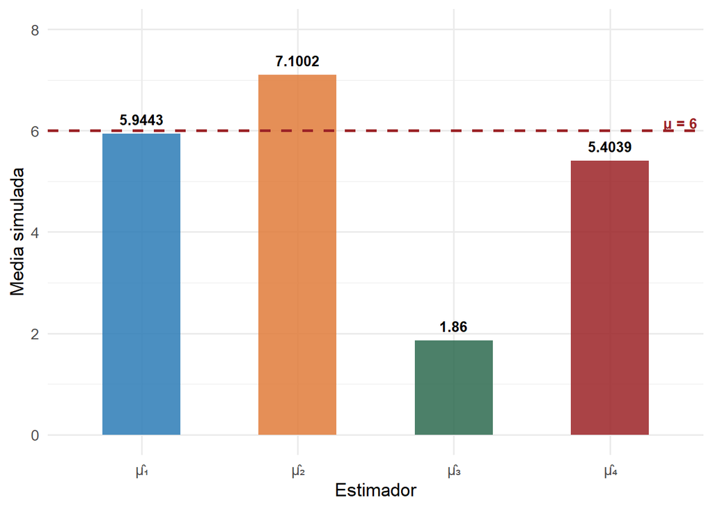

Figure 1.3: Comparación de medias simuladas vs. media poblacional

```r
ggplot(sesgos, aes(x = Estimador, y = Media_sim, fill = Estimador)) +
  geom_col(alpha = 0.85, width = 0.5) +
  geom_hline(yintercept = mu_pob, linetype = "dashed",
             color = "#9b2226", linewidth = 1) +
  geom_text(aes(label = round(Media_sim, 4)),
            vjust = -0.8, size = 3.5, fontface = "bold") +
  annotate("text", x = 4.45, y = mu_pob + 0.15,
           label = paste0("\u03bc = ", mu_pob),
           color = "#9b2226", size = 3.5, fontface = "bold") +
  scale_fill_manual(values = c("#2c7bb6","#e07b39","#2d6a4f","#9b2226")) +
  scale_y_continuous(limits = c(0, 8)) +
  labs(x = "Estimador", y = "Media simulada") +
  theme_minimal(base_size = 13) +
  theme(legend.position = "none")
```

La Tabla 1.1 y la Figura 1.3 muestran que $\hat{\mu}_1$ es el estimador con menor sesgo absoluto, seguido de $\hat{\mu}_4$. El sesgo de $\hat{\mu}_4$ es negativo porque divide entre $n+1$ en lugar de $n$, subestimando sistemáticamente la media. $\hat{\mu}_3$ presenta el mayor sesgo, ya que el mínimo muestral siempre tiende a ser menor que la media poblacional.

## 1.3 Consistencia

Un estimador es **consistente** si su variabilidad disminuye a medida que $n \to \infty$. Se mide con el **coeficiente de variación (CV)**:

$$CV = \frac{s_{\hat{\mu}}}{\bar{\hat{\mu}}} \times 100\%$$

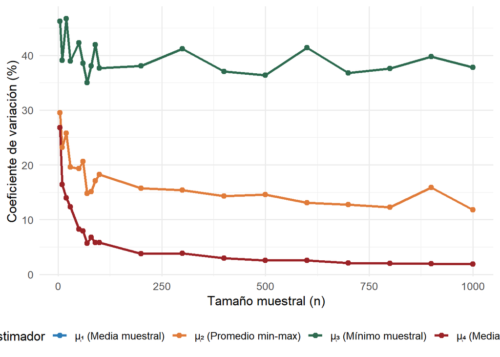

Figure 1.4: Variabilidad relativa (CV) de los estimadores según tamaño muestral

```r
set.seed(1005062032) # Codigo: Est Juan Alejandro Carrillo Jaimes
tamanios <- c(5, 10, 20, 30, 50, 60, 70, 80, 90,
              100, 200, 300, 400, 500, 600, 700, 800, 900, 1000)

cv_resultados <- lapply(tamanios, function(n) {
  muestras_n <- replicate(100, rgamma(n, shape = alpha_g, scale = sigma_g))
  e1 <- apply(muestras_n, 2, mean)
  e2 <- apply(muestras_n, 2, function(x) (min(x) + max(x)) / 2)
  e3 <- apply(muestras_n, 2, min)
  e4 <- apply(muestras_n, 2, function(x) sum(x) / (n + 1))
  data.frame(
    n   = n,
    CV1 = sd(e1) / mean(e1) * 100,
    CV2 = sd(e2) / mean(e2) * 100,
    CV3 = sd(e3) / mean(e3) * 100,
    CV4 = sd(e4) / mean(e4) * 100
  )
})

df_cv <- do.call(rbind, cv_resultados) |>
  tidyr::pivot_longer(cols = CV1:CV4,
                      names_to = "Estimador",
                      values_to = "CV") |>
  mutate(Estimador = recode(Estimador,
    CV1 = "\u03bc\u031c\u2081 (Media muestral)",
    CV2 = "\u03bc\u031c\u2082 (Promedio min-max)",
    CV3 = "\u03bc\u031c\u2083 (M\u00ednimo muestral)",
    CV4 = "\u03bc\u031c\u2084 (Media ajustada)"
  ))

ggplot(df_cv, aes(x = n, y = CV, color = Estimador)) +
  geom_line(linewidth = 1.1) +
  geom_point(size = 2) +
  scale_color_manual(values = c("#2c7bb6","#e07b39","#2d6a4f","#9b2226")) +
  labs(x = "Tamaño muestral (n)",
       y = "Coeficiente de variación (%)",
       color = "Estimador") +
  theme_minimal(base_size = 13) +
  theme(legend.position = "bottom")
```

## 1.4 Eficiencia

Un estimador es más **eficiente** si tiene menor varianza para el mismo tamaño muestral. Se compara mediante la varianza y el CV con $n = 10$:

```r
set.seed(1005062032) # Codigo: Est Juan Alejandro Carrillo Jaimes
muestras_ef <- replicate(100, rgamma(10, shape = alpha_g, scale = sigma_g))

e1 <- apply(muestras_ef, 2, mean)
e2 <- apply(muestras_ef, 2, function(x) (min(x) + max(x)) / 2)
e3 <- apply(muestras_ef, 2, min)
e4 <- apply(muestras_ef, 2, function(x) sum(x) / (10 + 1))

tabla_ef <- data.frame(
  Estimador = c("μ̂₁ (Media muestral)",
                "μ̂₂ (Promedio min-max)",
                "μ̂₃ (Mínimo muestral)",
                "μ̂₄ (Media ajustada)"),
  Media     = round(c(mean(e1), mean(e2), mean(e3), mean(e4)), 4),
  Varianza  = round(c(var(e1),  var(e2),  var(e3),  var(e4)),  4),
  CV        = round(c(sd(e1)/mean(e1), sd(e2)/mean(e2),
                      sd(e3)/mean(e3), sd(e4)/mean(e4)) * 100, 2)
)

knitr::kable(tabla_ef,
  caption   = "Comparación de eficiencia — varianza y CV (n = 10, 100 muestras)",
  col.names = c("Estimador", "Media", "Varianza", "CV (%)"),
  align     = c("l","c","c","c"),
  format    = "html"
) |>
  kableExtra::kable_styling(
    bootstrap_options = c("striped","hover","condensed"),
    full_width        = FALSE,
    position          = "center",
    font_size         = 14
  )
```

Table 1.2: Comparación de eficiencia — varianza y CV (n = 10, 100 muestras)

| Estimador | Media | Varianza | CV (%) |
| --- | --- | --- | --- |
| μ̂₁ (Media muestral) | 5.9443 | 1.1336 | 17.91 |
| μ̂₂ (Promedio min-max) | 7.1002 | 3.0958 | 24.78 |
| μ̂₃ (Mínimo muestral) | 1.8600 | 0.7216 | 45.67 |
| μ̂₄ (Media ajustada) | 5.4039 | 0.9368 | 17.91 |

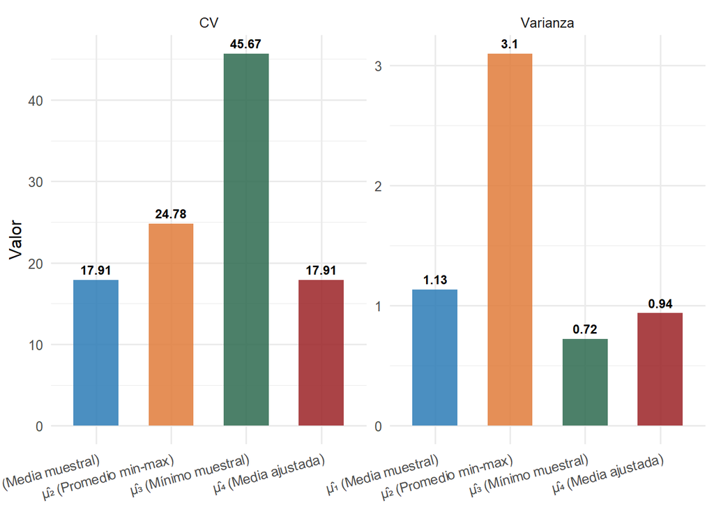

Figure 1.5: Comparación de varianza y CV entre estimadores (n = 10)

```r
df_ef_long <- tabla_ef |>
  tidyr::pivot_longer(cols = c(Varianza, CV),
                      names_to = "Metrica",
                      values_to = "Valor")

ggplot(df_ef_long, aes(x = Estimador, y = Valor, fill = Estimador)) +
  geom_col(alpha = 0.85, width = 0.6) +
  geom_text(aes(label = round(Valor, 2)),
            vjust = -0.6, size = 3.2, fontface = "bold") +
  scale_fill_manual(values = c("#2c7bb6","#e07b39","#2d6a4f","#9b2226")) +
  facet_wrap(~Metrica, scales = "free_y") +
  labs(x = NULL, y = "Valor") +
  theme_minimal(base_size = 12) +
  theme(legend.position = "none",
        axis.text.x = element_text(angle = 15, hjust = 1))
```